# MT_Project_LearnerNotebook_FullCode-Tayo Adeyo

### HyperparameterTuning of the Random Forest Model using the original dataset

```python
RFC_orig = RandomForestClassifier(random_state=1)

param_grid = {
    "n_estimators": [150, 200, 250, 300],
    "max_depth": np.arange(13, 20, 2),
    "min_samples_leaf": np.arange(1, 4),
    "max_features": [np.arange(0.3, 0.8, 0.1), "sqrt"],
    "max_samples": np.arange(0.4, 1, 0.1),
}

# Calling RandomizedSearchCV
randomized_cv = RandomizedSearchCV(
    estimator=RFC_orig,
    param_distributions=param_grid,
    n_iter=50,
    n_jobs=-1,
    scoring=scorer,
    cv=5,
    random_state=1,
)

# Fitting parameters in RandomizedSearchCV
randomized_cv.fit(X_train, y_train)

print(
    "Best parameters are {} with CV score={}:".format(
        randomized_cv.best_params_, randomized_cv.best_score_
    )
)
```

```
Best parameters are {'n_estimators': 150, 'min_samples_leaf': 1, 'max_samples': 0.7999999999999999, 'max_features': 'sqrt', 'max_depth': 19} with CV score=0.7140321766106342:
```

```python
# Creating the tuned random forest model with the best parameters
tuned_RFC_orig = RandomForestClassifier(
    max_depth=19,
    max_features="sqrt",
    random_state=1,
    max_samples=0.8,
    n_estimators=150,
    min_samples_leaf=1,
)

tuned_RFC_orig.fit(X_train, y_train)
```

```
RandomForestClassifier(max_depth=19, max_features='sqrt', max_samples=0.8,
                       n_estimators=150, random_state=1)
```

```python
tuned_RFC_orig_train = model_performance_classification_sklearn(
    tuned_RFC_orig, X_train, y_train
)
print("Performance on the Training dataset")
tuned_RFC_orig_train
```

```
Performance on the Training dataset
```

|  | Accuracy | Recall | Precision | F1 |
| --- | --- | --- | --- | --- |
| 0 | 0.995 | 0.907 | 1.000 | 0.951 |

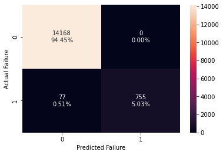

```python
# Creating confusion matrix for the Training dataset
confusion_matrix_sklearn(tuned_RFC_orig, X_train, y_train)
```

```python
tuned_RFC_orig_val = model_performance_classification_sklearn(
    tuned_RFC_orig, X_val, y_val
)
print("Performance on the validation dataset")
tuned_RFC_orig_val
```

```
Performance on the validation dataset
```

|  | Accuracy | Recall | Precision | F1 |
| --- | --- | --- | --- | --- |
| 0 | 0.984 | 0.723 | 0.990 | 0.836 |

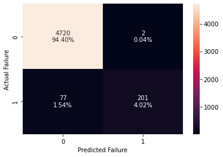

```python
# Creating confusion matrix for the validation dataset
confusion_matrix_sklearn(tuned_RFC_orig, X_val, y_val)
```

- The tuned Random Forest model with original data is **NOT** generalizing well. We can only predict 4.02% of the failure out of 5.56% of machine failures and the false negative % is high - 1.54%.

### HyperparameterTuning of the XGBoost Model using the oversampled dataset

```python
# defining the model
XGB_over = XGBClassifier(random_state=1, eval_metric="logloss")

# Parameter grid to pass in RandomSearchCV
param_grid = {
    "n_estimators": [150, 200, 250],
    "max_depth": [3, 5, 7],
    "scale_pos_weight": [5, 10],
    "learning_rate": [0.1, 0.2],
    "gamma": [0, 3, 5],
    "subsample": [0.8, 0.9],
}

# Calling RandomizedSearchCV
randomized_cv = RandomizedSearchCV(
    estimator=XGB_over,
    param_distributions=param_grid,
    n_iter=20,
    n_jobs=-1,
    scoring=scorer,
    cv=5,
    random_state=1,
)

# Fitting parameters in RandomizedSearchCV
randomized_cv.fit(X_train_over, y_train_over)

print(
    "Best parameters are {} with CV score={}:".format(
        randomized_cv.best_params_, randomized_cv.best_score_
    )
)
```

```
Best parameters are {'subsample': 0.9, 'scale_pos_weight': 10, 'n_estimators': 250, 'max_depth': 5, 'learning_rate': 0.1, 'gamma': 3} with CV score=0.9959064219685276:
```

```python
# Creating new pipeline with best parameters
tuned_XGB_over = XGBClassifier(
    random_state=1,
    eval_metric="logloss",
    subsample=0.9,
    scale_pos_weight=10,
    n_estimators=250,
    max_depth=5,
    learning_rate=0.1,
    gamma=3,
)

tuned_XGB_over.fit(X_train_over, y_train_over)
```

```
XGBClassifier(base_score=None, booster=None, callbacks=None,
              colsample_bylevel=None, colsample_bynode=None,
              colsample_bytree=None, early_stopping_rounds=None,
              enable_categorical=False, eval_metric='logloss',
              feature_types=None, gamma=3, gpu_id=None, grow_policy=None,
              importance_type=None, interaction_constraints=None,
              learning_rate=0.1, max_bin=None, max_cat_threshold=None,
              max_cat_to_onehot=None, max_delta_step=None, max_depth=5,
              max_leaves=None, min_child_weight=None, missing=nan,
              monotone_constraints=None, n_estimators=250, n_jobs=None,
              num_parallel_tree=None, predictor=None, random_state=1, ...)
```

```python
tuned_XGB_over_train = model_performance_classification_sklearn(
    tuned_XGB_over, X_train_over, y_train_over
)
print("Performance on the Training dataset")
tuned_XGB_over_train
```

```
Performance on the Training dataset
```

|  | Accuracy | Recall | Precision | F1 |
| --- | --- | --- | --- | --- |
| 0 | 0.994 | 1.000 | 0.989 | 0.994 |

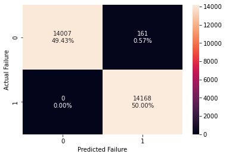

```python
# Creating confusion matrix for the train dataset
confusion_matrix_sklearn(tuned_XGB_over, X_train_over, y_train_over)
```

```python
tuned_XGB_over_val = model_performance_classification_sklearn(
    tuned_XGB_over, X_val, y_val
)
print("Performance on the Validation dataset")
tuned_XGB_over_val
```

```
Performance on the Validation dataset
```

|  | Accuracy | Recall | Precision | F1 |
| --- | --- | --- | --- | --- |
| 0 | 0.969 | 0.885 | 0.668 | 0.762 |

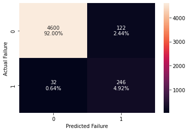

```python
# Creating confusion matrix for the Validation dataset
confusion_matrix_sklearn(tuned_XGB_over, X_val, y_val)
```

- The tuned XGBoost model with oversampled data seems to generalize well. We are able to predict the failure of at least 4.92% out of 5.56% of machine failures and false negative % is not too high - 0.64%. But this model seems to be overfitting the training data

### HyperparameterTuning of the Random Forest Model using the undersampled dataset

```python
RFC_under = RandomForestClassifier(random_state=1)

param_grid = {
    "max_depth": np.arange(6, 13, 2),
    "n_estimators": [200, 250, 300],
    "min_samples_leaf": np.arange(1, 4),
    "max_features": [np.arange(0.3, 0.6, 0.1), "sqrt"],
    "max_samples": np.arange(0.4, 1, 0.1),
}

# Calling RandomizedSearchCV
randomized_cv = RandomizedSearchCV(
    estimator=RFC_under,
    param_distributions=param_grid,
    n_iter=50,
    n_jobs=-1,
    scoring=scorer,
    cv=5,
    random_state=1,
)

# Fitting parameters in RandomizedSearchCV
randomized_cv.fit(X_train, y_train)

print(
    "Best parameters are {} with CV score={}:".format(
        randomized_cv.best_params_, randomized_cv.best_score_
    )
)
```

```
Best parameters are {'n_estimators': 200, 'min_samples_leaf': 2, 'max_samples': 0.6, 'max_features': 'sqrt', 'max_depth': 12} with CV score=0.6587836375441887:
```

```python
# Creating the tuned random forest model with the best parameters
tuned_RFC_under = RandomForestClassifier(
    max_depth=12,
    max_features="sqrt",
    random_state=1,
    max_samples=0.6,
    n_estimators=200,
    min_samples_leaf=2,
)

tuned_RFC_under.fit(X_train_under, y_train_under)
```

```
RandomForestClassifier(max_depth=12, max_features='sqrt', max_samples=0.6,
                       min_samples_leaf=2, n_estimators=200, random_state=1)
```

```python
tuned_RFC_under_train = model_performance_classification_sklearn(
    tuned_RFC_under, X_train_under, y_train_under
)
print("Performance on the Training dataset")
tuned_RFC_under_train
```

```
Performance on the Training dataset
```

|  | Accuracy | Recall | Precision | F1 |
| --- | --- | --- | --- | --- |
| 0 | 0.965 | 0.935 | 0.995 | 0.964 |

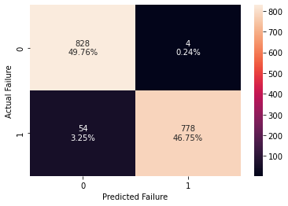

```python
# Creating confusion matrix for the Training dataset
confusion_matrix_sklearn(tuned_RFC_under, X_train_under, y_train_under)
```

```python
tuned_RFC_under_val = model_performance_classification_sklearn(
    tuned_RFC_under, X_val, y_val
)
print("Performance on the validation dataset")
tuned_RFC_under_val
```

```
Performance on the validation dataset
```

|  | Accuracy | Recall | Precision | F1 |
| --- | --- | --- | --- | --- |
| 0 | 0.942 | 0.885 | 0.489 | 0.630 |

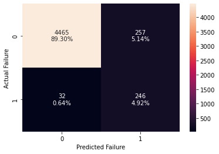

```python
# Creating confusion matrix for the Validation dataset
confusion_matrix_sklearn(tuned_RFC_under, X_val, y_val)
```

- The tuned Random Forest model with undersampled data seems to generalize well. we are able to predict the failure of at least 4.92% out of 5.56% of machine failures and false negative % is not too high - 0.64%. This model is not overfitting the training data.

### HyperparameterTuning of the Gradient Boost Model using the undersampled dataset

```python
# defining the model
GBC_under = GradientBoostingClassifier(random_state=1)

# Parameter grid to pass in RandomSearchCV
param_grid = {
    "max_depth": [2, 3],
    "n_estimators": np.arange(50, 125, 25),
    "learning_rate": [0.2, 0.05, 1],
    "subsample": [0.5, 0.7, 0.9],
    "max_features": [0.5, 0.7, 0.9],
}
# Calling RandomizedSearchCV
randomized_cv = RandomizedSearchCV(
    estimator=GBC_under,
    param_distributions=param_grid,
    scoring=scorer,
    n_iter=40,
    n_jobs=-1,
    cv=5,
    random_state=1,
)

# Fitting parameters in RandomizedSearchCV
randomized_cv.fit(X_train_under, y_train_under)

print(
    "Best parameters are {} with CV score={}:".format(
        randomized_cv.best_params_, randomized_cv.best_score_
    )
)
```

```
Best parameters are {'subsample': 0.7, 'n_estimators': 100, 'max_features': 0.7, 'max_depth': 2, 'learning_rate': 0.2} with CV score=0.8990332587836376:
```

```python
tuned_GBM_under = GradientBoostingClassifier(
    random_state=1,
    learning_rate=0.2,
    max_depth=2,
    max_features=0.7,
    n_estimators=100,
    subsample=0.7,
)

tuned_GBM_under.fit(X_train_under, y_train_under)
```

```
GradientBoostingClassifier(learning_rate=0.2, max_depth=2, max_features=0.7,
                           random_state=1, subsample=0.7)
```

```python
tuned_GBM_under_train = model_performance_classification_sklearn(
    tuned_GBM_under, X_train_under, y_train_under
)
print("Performance on the Training dataset")
tuned_GBM_under_train
```

```
Performance on the Training dataset
```

|  | Accuracy | Recall | Precision | F1 |
| --- | --- | --- | --- | --- |
| 0 | 0.960 | 0.938 | 0.982 | 0.959 |

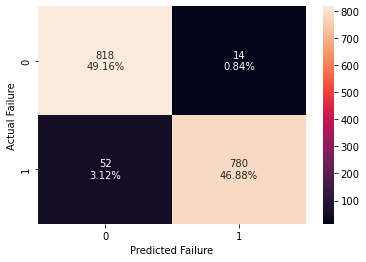

```python
# Creating confusion matrix for the Training dataset
confusion_matrix_sklearn(tuned_GBM_under, X_train_under, y_train_under)
```

```python
tuned_GBM_under_val = model_performance_classification_sklearn(
    tuned_GBM_under, X_val, y_val
)
print("Performance on the Validation dataset")
tuned_GBM_under_val
```

```
Performance on the Validation dataset
```

|  | Accuracy | Recall | Precision | F1 |
| --- | --- | --- | --- | --- |
| 0 | 0.909 | 0.885 | 0.367 | 0.519 |

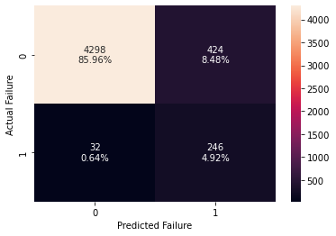

```python
# Creating confusion matrix for the Validation dataset
confusion_matrix_sklearn(tuned_GBM_under, X_val, y_val)
```

## Model performance comparison and choosing the final model

```python
# Model performance comparison for Training dataset

models_train_comp_df = pd.concat(
    [
        tuned_XGB_orig_train.T,
        tuned_XGB_over_train.T,
        tuned_RFC_orig_train.T,
        tuned_RFC_under_train.T,
        tuned_GBM_under_train.T,
    ],
    axis=1,
)
models_train_comp_df.columns = [
    "XGBoost with original data",
    "XGBoost with oversampled data",
    "RandomForest with original data",
    "RandomForest with undersampled data",
    "GradientBoost with undersampled data",
]
print("Comparison of Performance on Training data:")
models_train_comp_df
```

```
Comparison of Performance on Training data:
```

|  | XGBoost with original data | XGBoost with oversampled data | RandomForest with original data | RandomForest with undersampled data | GradientBoost with undersampled data |
| --- | --- | --- | --- | --- | --- |
| Accuracy | 0.996 | 0.994 | 0.995 | 0.965 | 0.960 |
| Recall | 0.982 | 1.000 | 0.907 | 0.935 | 0.938 |
| Precision | 0.940 | 0.989 | 1.000 | 0.995 | 0.982 |
| F1 | 0.961 | 0.994 | 0.951 | 0.964 | 0.959 |

```python
# Model performance comparison for Validation dataset

models_train_comp_df = pd.concat(
    [
        tuned_XGB_orig_val.T,
        tuned_XGB_over_val.T,
        tuned_RFC_orig_val.T,
        tuned_RFC_under_val.T,
        tuned_GBM_under_val.T,
    ],
    axis=1,
)
models_train_comp_df.columns = [
    "XGBoost with original data",
    "XGBoost with oversampled data",
    "RandomForest with original data",
    "RandomForest with undersampled data",
    "GradientBoost with undersampled data",
]
print("Comparison of Performance on Validation data:")
models_train_comp_df
```

```
Comparison of Performance on Validation data:
```

|  | XGBoost with original data | XGBoost with oversampled data | RandomForest with original data | RandomForest with undersampled data | GradientBoost with undersampled data |
| --- | --- | --- | --- | --- | --- |
| Accuracy | 0.985 | 0.969 | 0.984 | 0.942 | 0.909 |
| Recall | 0.863 | 0.885 | 0.723 | 0.885 | 0.885 |
| Precision | 0.866 | 0.668 | 0.990 | 0.489 | 0.367 |
| F1 | 0.865 | 0.762 | 0.836 | 0.630 | 0.519 |

- The best models are:
  - 1. The XGBoost model with oversampled data
  - 1. The Random Forest model with undersampled data
  - 1. Gradient Boost model with undersampled data
- Out of these three, we will choose the XGboost model with oversampled data as our final model. We do this because of this model's predictive ability especially when its other metrics like precision and accuracy are compared with those of the other two models.

### Performance of the chosen final model on the test dataset.

```python
# Performance of the Tuned XGB model with oversampled data on the Testing Dataset
tuned_XGB_over_test = model_performance_classification_sklearn(
    tuned_XGB_over, X_test, y_test
)
print("Performance on the Test dataset")
tuned_XGB_over_test
```

```
Performance on the Test dataset
```

|  | Accuracy | Recall | Precision | F1 |
| --- | --- | --- | --- | --- |
| 0 | 0.966 | 0.869 | 0.652 | 0.745 |

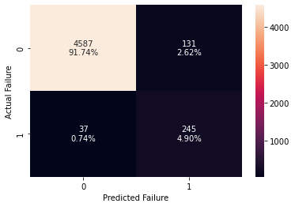

```python
# Creating confusion matrix for the Test dataset
confusion_matrix_sklearn(tuned_XGB_over, X_test, y_test)
```

- The XGBoost model with oversampled data seems to generalize well on the test dataset. We are able to predict the failure of at least 4.90% out of 5.64% of machine failures and false negative % is not too high - 0.74%.

#### Test data Performance on tuned_RFC_under model

```
Performance on the Test dataset:

   Accuracy  Recall  Precision    F1
0     0.942   0.879      0.494 0.633
```

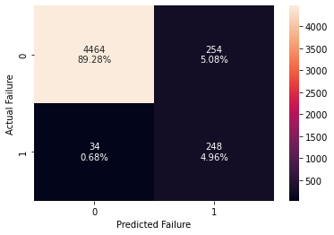

```python
# Performance of the Tuned XGB model with oversampled data on the Testing Dataset
tuned_RFC_under_test = model_performance_classification_sklearn(
    tuned_RFC_under, X_test, y_test
)
print("Performance on the Test dataset:\n")
print(tuned_RFC_under_test, "\n")

# Creating confusion matrix for the Test dataset
confusion_matrix_sklearn(tuned_RFC_under, X_test, y_test)
```

- A high False positive, that is when a failure is reported, but there is actually no failure leads to unneccessary inspection costs. The recall score of the XGboost model and the Random forest model are similar, but the random forest model has a disproportionate high false positive, 254 (5.08%) inspections with its attendant costs as opposed to 131 (2.62%) inspections that results from using the XGBoost model. Hence our choice of the XGBoost model as our final model.

### Feature Importances

```python
# Printing the Gini importance of the predictor variables
print(
    pd.DataFrame(
        tuned_XGB_over.feature_importances_, columns=["Imp"], index=X_train_over.columns
    ).sort_values(by="Imp", ascending=False)
)
```

```
      Imp
V36 0.139
V26 0.055
V14 0.048
V16 0.046
V18 0.046
V1  0.037
V21 0.037
V39 0.036
V34 0.026
V10 0.025
V9  0.025
V15 0.024
V37 0.024
V23 0.023
V3  0.022
V6  0.022
V33 0.021
V4  0.020
V30 0.019
V2  0.019
V5  0.017
V35 0.017
V12 0.017
V28 0.017
V13 0.017
V11 0.016
V24 0.016
V38 0.016
V40 0.015
V7  0.014
V19 0.014
V17 0.013
V29 0.013
V32 0.013
V27 0.013
V31 0.011
V22 0.011
V25 0.011
V8  0.011
V20 0.010
```

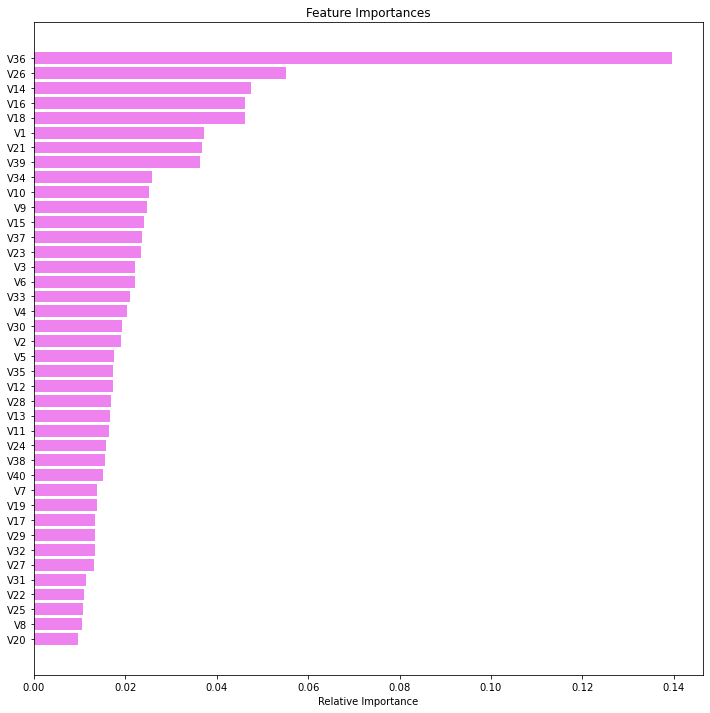

```python
# Display the most important features for the our final model
feature_names = X_test.columns
importances = tuned_XGB_over.feature_importances_
indices = np.argsort(importances)

plt.figure(figsize=(12, 12))
plt.title("Feature Importances")
plt.barh(range(len(indices)), importances[indices], color="violet", align="center")
plt.yticks(range(len(indices)), [feature_names[i] for i in indices])
plt.xlabel("Relative Importance")
plt.show()
```

- The topmost predictors of whether a machine will fail or not are V36, V26, V14, V16 and V18 in that order.

## Pipelines to build the final model

```python
# Dividing the Train dataset into X and Y datasets
Xp_train = df_train.drop(["Target"], axis=1)
Yp_train = df_train["Target"]
```

```python
# Dividing the Test dataset into X and y datasets
Xp_test = df_test.drop(["Target"], axis=1)
yp_test = df_test["Target"]
```

```python
# Imputing the missing values in the train set
imputer = SimpleImputer(strategy="median")
Xp_train = imputer.fit_transform(Xp_train)
```

```python
# Synthetic Minority Over Sampling Technique
sm = SMOTE(sampling_strategy=1, k_neighbors=5, random_state=1)
Xp_train_over, yp_train_over = sm.fit_resample(Xp_train, Yp_train)
```

```python
# Creating new pipeline with best parameters
model = Pipeline(
    steps=[
        ("imputer", SimpleImputer(strategy="median")),
        (
            "XGB_tuned",
            XGBClassifier(
                random_state=1,
                eval_metric="logloss",
                subsample=0.9,
                scale_pos_weight=10,
                n_estimators=250,
                max_depth=5,
                learning_rate=0.1,
                gamma=3,
            ),
        ),
    ]
)
# Fit the model on training data
model.fit(Xp_train_over, yp_train_over)
```

```
Pipeline(steps=[('imputer', SimpleImputer(strategy='median')),
                ('XGB_tuned',
                 XGBClassifier(base_score=None, booster=None, callbacks=None,
                               colsample_bylevel=None, colsample_bynode=None,
                               colsample_bytree=None,
                               early_stopping_rounds=None,
                               enable_categorical=False, eval_metric='logloss',
                               feature_types=None, gamma=3, gpu_id=None,
                               grow_policy=None, importance_type=None,
                               interaction_constraints=None, learning_rate=0.1,
                               max_bin=None, max_cat_threshold=None,
                               max_cat_to_onehot=None, max_delta_step=None,
                               max_depth=5, max_leaves=None,
                               min_child_weight=None, missing=nan,
                               monotone_constraints=None, n_estimators=250,
                               n_jobs=None, num_parallel_tree=None,
                               predictor=None, random_state=1, ...))])
```

```python
# Predict the failed generators within the testing data
model.predict(Xp_test)
```

```
array([0, 0, 0, ..., 0, 0, 0])
```

```python
# Calculating different metrics on Test dataset
model_perf = model_performance_classification_sklearn(model, Xp_test, yp_test)
print("Test performance:")
model_perf
```

```
Test performance:
```

|  | Accuracy | Recall | Precision | F1 |
| --- | --- | --- | --- | --- |
| 0 | 0.961 | 0.865 | 0.607 | 0.713 |

# Business Insights and Conclusions

- We are unable to carry out a comprehensive exploratory data analysis on the dataset provided due to the lack of useful information on the sensor variables. It would have been good to have some insight into some of these variables as this would have been of help to us in our effort to pass along as much insight as we could so as to help the company further in their research into the behavioural patterns of their wind genetaors.
- We have built a machine learning model that has the ability to predict with a reasonable degree of certainty whether a generator amongst Renewind's collecton of wind generators will fail or not and has therefore provided Renewind a platform with which their overall maintenance and repair costs could be kept to the barest minimum.
- We have chosen the XGBoost model with oversampled data as our final model. This model was chosen over two others with similar performances as explained in part of our notes above. The XGBoost model generalizes well and its predictive ability on some of the other metrics is much better than that of the other models that could have been chosen for production.
- The topmost predictor variables of whether a generator will fail or not are V36, V26, V14, V16 and V18 in that order.
- We have also productionise the final model by building a pipeline for it.